# Monitoramento do Programa UPA 24h

26 de outubro de 2018

## A PESQUISA

## OBJETO E OBJETIVOS

OBJETO

O Programa UPA 24h do Ministério da Saúde. A situação da implantação das Unidades de Pronto Atendimento - UPA 24h no país, considerando seus diferentes portes.

OBJETIVOS

- Descrever panorama da situação de implantação das UPA no país
- Descrever panorama das UPA 24h em funcionamento no país considerando seu porte e atendimento
- Identificar dificuldades na implantação do Programa comparando o perfil de atendimento existente com o universo de oferta inicialmente previsto

## CONTEXTO E MÉTODO

## Contexto

Avaliação de um programa que completou 10 anos, num contexto de deficiência da Rede Atenção às Urgência, ainda com superlotação de hospitais, com demanda crescente de atendimento e corte de recursos. Estados e municípios com dificuldades de implantação e manutenção das UPA já financiadas, solicitando alteração da função das unidades inicialmente propostas.

## Método

Para a análise foram utilizadas 2 planilhas Excel com dados de 30/08/18. A primeira planilha de uso interno da Coordenação-Geral de Urgência e Emergência do Ministério da Saúde, com o controle resumo das propostas de implantação das UPA em andamento no país. Para esta foi necessário o trabalho de limpeza.  
Após a primeira tentativa de importação com o função read.xlsx e observação inicial de resultado, optei por uma simplificação dos nomes das colunas, ainda em excel, e retirada de textos em campos que identificavam valor ou códigos, bem como a substituição de zero por vazio em alguns campos, para realizar novamente a importação.  
A segunda planilha, recebida mensalmente, tem dados extraídos do Sistema SIA/SUS, com a produção consolidada por procedimentos realizados de todas as UPA, nos meses de janeiro a junho de 2018. Na importação desta não foi necessária limpeza dos dados.  
Foram importadas assim 2 tabelas para análise: "controleupa", "producaoupa".

## MONITORAMENTO DO PROGRAMA UPA 24h NO BRASIL

1º SEMESTRE DE 2018

A UPA 24h é um estabelecimento de saúde que compõe a Rede de Atenção às Urgências. É de complexidade intermediária, e deve atuar em conjunto com a Atenção Básica e o SAMU 192 de um lado, e a Atenção Hospitalar e a Atenção Domiciliar de outro. Iniciado pelo Ministério da Saúde em 2008, o Programa UPA 24h incentiva a construção e implantação de Unidades de Pronto Atendimento-UPA, visando melhorar os serviços de urgência e reduzir a superlotação dos hospitais.

A implantação é prevista para municípios de no mínimo 50.000 habitantes, com atendimento regionalizado. As UPA têm sua estrutura física e de atendimento classificada em Portes:

- Porte I - De 50.000 a 100.000 habitantes
- Porte II - 100.001 a 200.000
- Porte III - 200.001 a 300.000

## Implantação das UPA 24h no Brasil

Atualmente existem no Brasil mais de 600 UPA 24h em funcionamento. Temos no entanto mais de 180 ainda em obras, e 141 unidades com obras concluídas que não iniciaram seu funcionamento.

| **Situação** | **Nr UPA** | **%** |
| --- | --- | --- |
| Ação preparatória | 11 | 1,2 |
| Em obras | 187 | 19,9 |
| Concluída | 141 | 15 |
| Em funcionamento | 602 | 64 |

Fonte: CGUE- Ministério da Saúde -30/08/18

## Implantação das UPA 24h no Brasil

Ao longo dos anos verifica-se a dificuldade de conclusão das obras e de início de funcionamento das unidades,a despeito do tempo e recurso repassado.

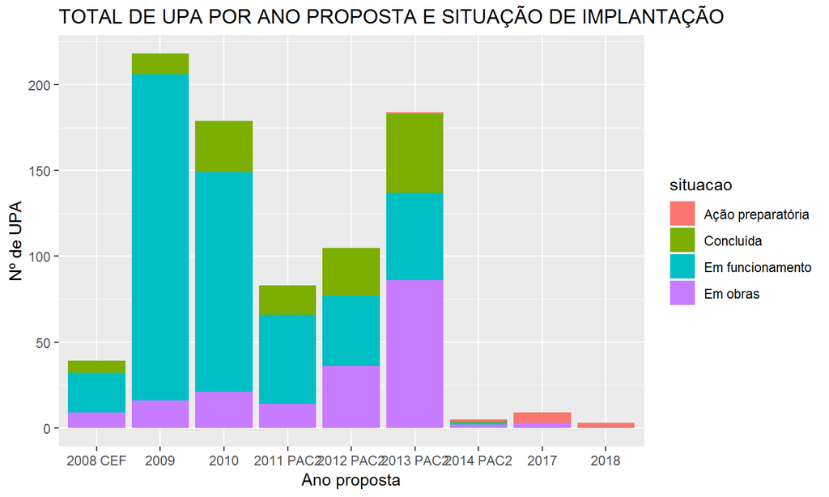

A seguir a distribuição das UPA do Programa por porte no país.

## UPA EM IMPLANTAÇÃO

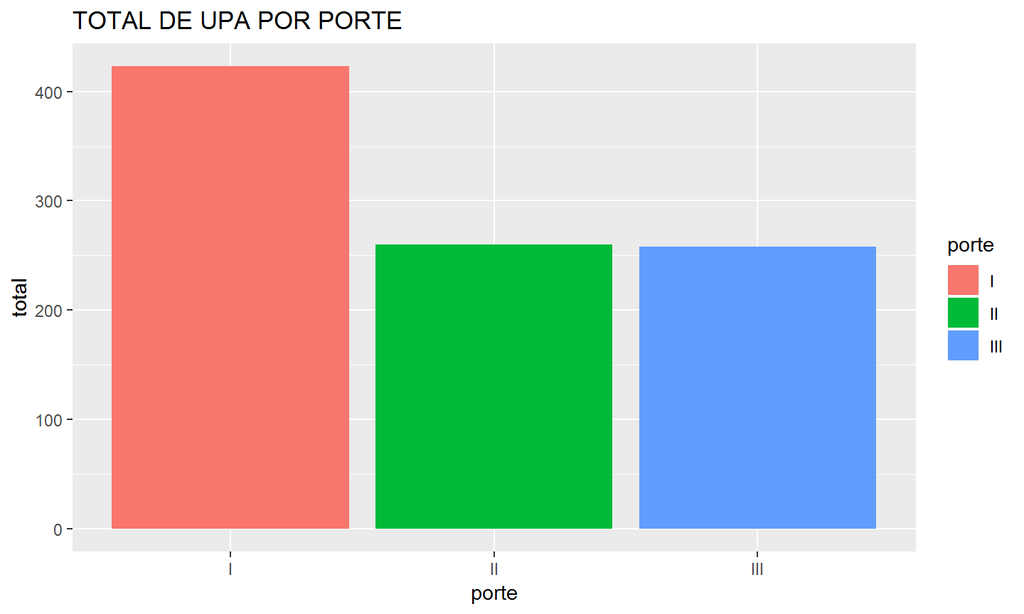

As propostas de implantação de UPA Porte I se apresentaram em maior número.

## UPA EM FUNCIONAMENTO

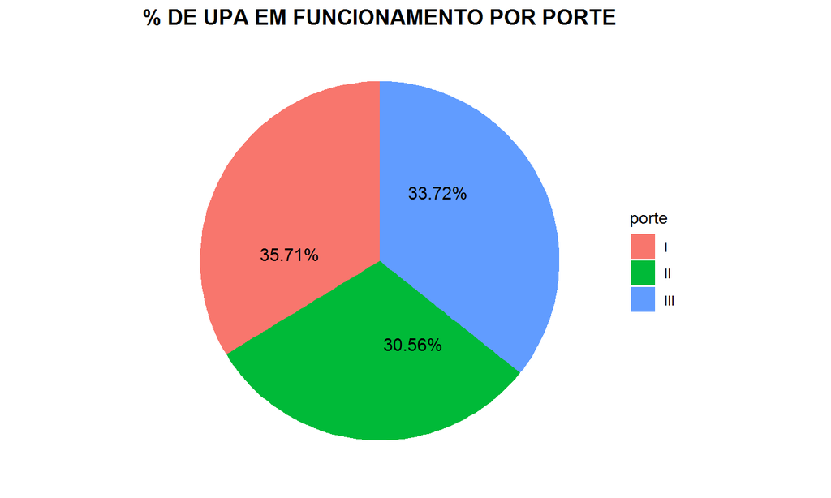

Considerando somente as UPA que iniciaram funcionamento, verifica-se uma distribuição mais homogênea entre os portes.

## UPA POR PORTE NOS ESTADOS

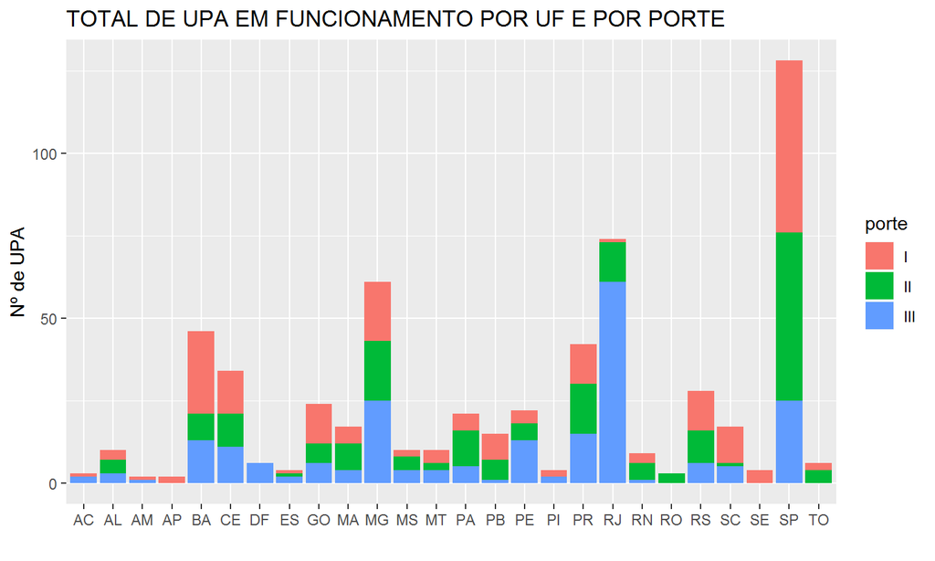

Pela relação direta com o contingente da população atingida na definção das UPA, percebe-se a concentração de UPA nos estados da região Sudeste, Bahia,Ceará e Paraná, bem como a concentração nestes estados, das UPA de maior porte.

## MONITORAMENTO DA PRODUÇÃO DAS UPA

Considerando as UPA já em funcionamento, temos uma média de atendimentos esperados, para cada opção de capacidade de atendimento,que seria em torno de  
4.500 atendimentos/mês nas unidades Porte I,  
6.750 nas Porte II, e  
10.125 nas Porte III.

A seguir gráficos da média mensal de atendimentos realizados nas UPA por porte. Dados do 1º semestre de 2018.

## PRODUÇÃO DAS UPA - DISTRIBUIÇÃO POR ESTADOS

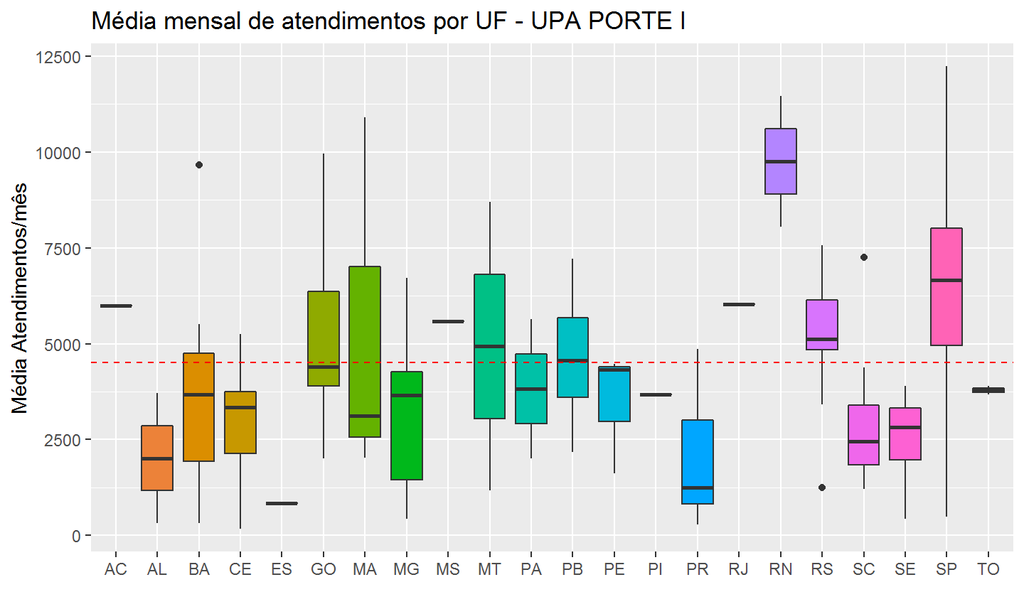

## PRODUÇÃO DAS UPA - DISTRIBUIÇÃO POR ESTADOS

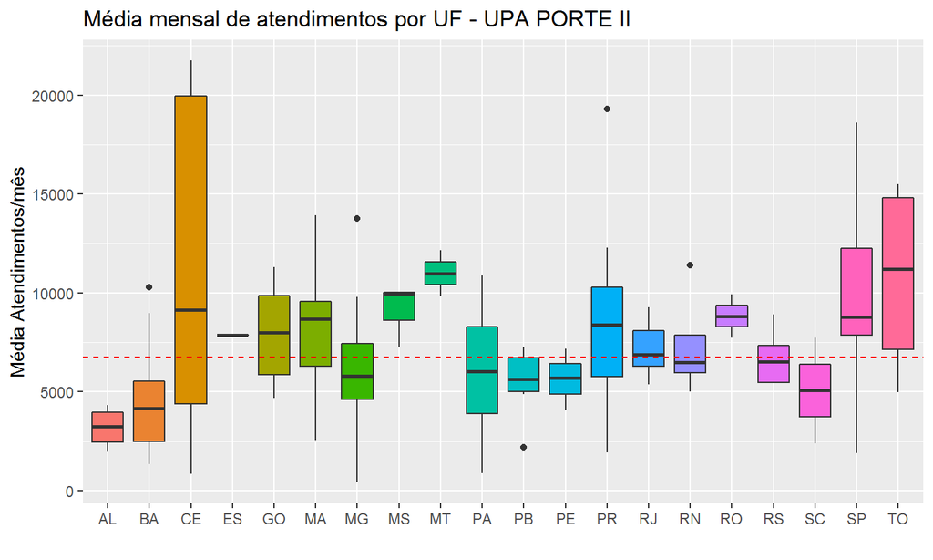

## PRODUÇÃO DAS UPA - DISTRIBUIÇÃO POR ESTADOS

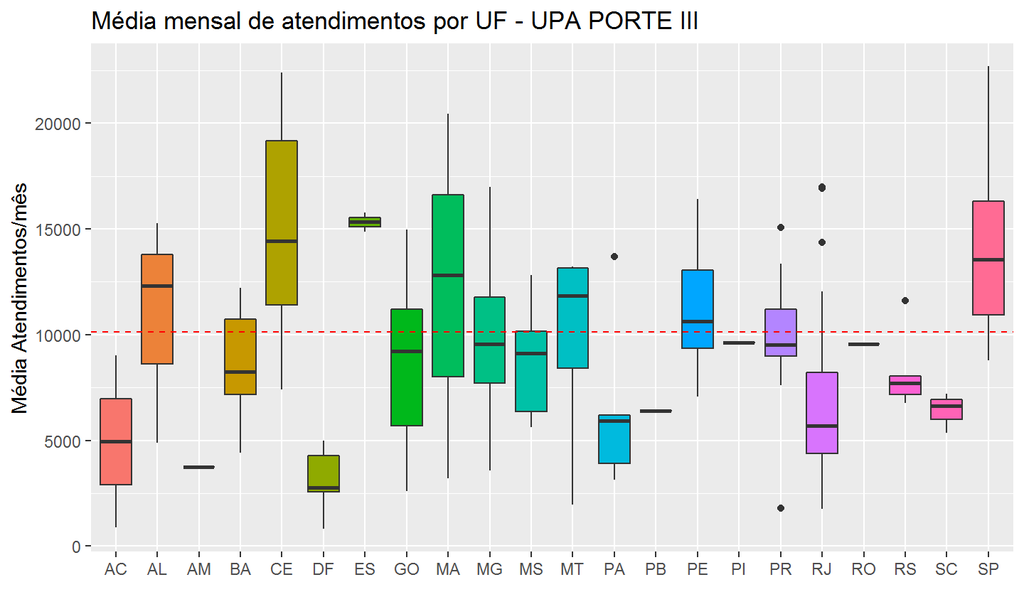

## CONSIDERAÇÕES SOBRE A EVOLUÇÃO DE IMPLANTAÇÃO DAS UPA

Observa-se desde o início do Programa um número considerável de unidades que não chegam a ter obras concluídas ou iniciando seu funcionamento, demostrando a dificuldade de municípios e estados em cumprir o solicitado, apesar do investimento recebido.Isto poderia estar associado a questões de gestão.  
O crescimento deste número, ano a ano, no entanto, pode indicar falta de condições financeiras de estados e municípios para implantar as UPA, e defasagem dos valores de incentivo repassados, já que os custos totais são partilhados entre os governos federal, estadual e municipal.

## CONSIDERAÇÕES SOBRE A PRODUÇÃO DAS UPA

Os dados mostram que em média as UPA Porte I estão com atendimento abaixo ou bem próximo do esperado. As de Porte II circulam mais em torno do esperado e em muitos casos estão bem acima em vários estados, e as UPA Porte III mostram um número maior de estados com atendimento abaixo do esperado.

Ficou evidente também que dentro do grupo de UPA de cada porte há uma variação muito grande da média de atendimentos realizados, apontando uma discrepância entre a definição do porte e a real demanda local.